# High matrix vegetation decreases mean seed dispersal distance but increases long wind dispersal probability connecting local plant populations in agricultural landscapes - ScienceDirect

## Figures (4)

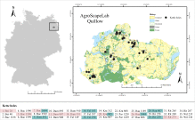

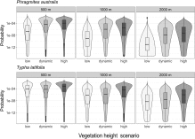

## Tables (1)

1. Table 1

## Extras (1)

1. Supplementary material.

[figure not shown]

## [Agriculture, Ecosystems & Environment](https://www.sciencedirect.com/journal/agriculture-ecosystems-and-environment)

[Volume 322](https://www.sciencedirect.com/journal/agriculture-ecosystems-and-environment/vol/322/suppl/C), 1 December 2021, 107678

# High matrix vegetation decreases mean seed dispersal distance but increases long wind dispersal probability connecting local plant populations in agricultural landscapes

[SissiLozada-Gobilard<sup>a</sup><sup>b</sup><sup>1</sup>](https://www.sciencedirect.com/science/article/pii/S0167880921003820#!)[FlorianJeltsch<sup>c</sup><sup>d</sup><sup>2</sup>](https://www.sciencedirect.com/science/article/pii/S0167880921003820#!)[JinleiZhu<sup>e</sup><sup>3</sup>](https://www.sciencedirect.com/science/article/pii/S0167880921003820#!)

https://doi.org/10.1016/j.agee.2021.107678[Get rights and content](https://s100.copyright.com/AppDispatchServlet?publisherName=ELS&contentID=S0167880921003820&orderBeanReset=true)

## Highlights

**•**

Mean dispersal distance decreases with increasing vegetation height.

**•**

Probability of long-distance dispersal (LDD) increases with vegetation height.

**•**

The vegetation-induced trade-off between mean dispersal distance and LDD impacts connectivity among kettle holes.

**•**

Vegetation height affects landscape connectivity and (meta-) population and community dynamics of wind-dispersed plants.

## Abstract

[Seed dispersal](https://www.sciencedirect.com/topics/earth-and-planetary-sciences/seed-dispersal) plays an important role in population dynamics in agricultural ecosystems, but the effects of surrounding vegetation height on seed dispersal and population connectivity on the landscape scale have rarely been studied. Understanding the effects of surrounding vegetation height on seed dispersal will provide important information for land-use management in agricultural landscapes to prevent the spread of undesired weeds or enhance functional connectivity. We used two model species, *[Phragmites australis](https://www.sciencedirect.com/topics/agricultural-and-biological-sciences/phragmites-australis)* and *[Typha latifolia](https://www.sciencedirect.com/topics/agricultural-and-biological-sciences/typha-latifolia)**,* growing in small natural ponds known as [kettle holes](https://www.sciencedirect.com/topics/earth-and-planetary-sciences/kettle-hole), in an agricultural landscape to evaluate the effects of surrounding vegetation height on wind dispersal and population connectivity between kettle holes. Seed dispersal distance and the probability of long-distance dispersal (LDD) were simulated with the mechanistic WALD model under three scenarios of “low”, “dynamic” and “high” surrounding vegetation height. Connectivity between the origin and target kettle holes was quantified with a connectivity index adapted from Hanski and Thomas (1994). Our results show that mean seed dispersal distance decreases with the height of surrounding matrix vegetation, but the probability of long-distance dispersal (LDD) increases with vegetation height. This indicates an important vegetation-based trade-off between mean dispersal distance and LDD, which has an impact on connectivity. Matrix vegetation height has a negative effect on mean seed dispersal distance but a positive effect on the probability of LDD. This positive effect and its impact on connectivity provide novel insights into landscape level (meta-)population and community dynamics — a change in matrix vegetation height by land-use or climatic changes could strongly affect the spread and connectivity of wind-dispersed plants. The opposite effect of vegetation height on mean seed dispersal distance and the probability of LDD should therefore be considered in management and analyses of future land-use and climate change effects.

## Keywords

Seed dispersal by wind

Long-distance seed dispersal

Matrix vegetation

Kettle holes

Agricultural landscapes

Metapopulation dynamics

## 1. Introduction

The effective dispersal of seeds and pollen among suitable habitat patches determines the plant functional connectivity in fragmented landscapes (Auffret et al., 2017). [Seed dispersal](https://www.sciencedirect.com/topics/earth-and-planetary-sciences/seed-dispersal) is typically assumed to be the most important process connecting local plant populations in such isolated habitat patches (Figuerola and Green, 2002, Soons et al., 2016), although the importance of pollen transfer has also been highlighted in several studies (e.g., Harmon-Threatt et al., 2009; Schermer et al., 2019). Dispersal of pollen and seeds in plants is mediated through biotic and abiotic vectors such as animals, wind, or water (Aavik et al., 2014). The dynamics of these vectors are largely impacted by the landscape configuration which thus determines the degree of connectivity of suitable habitat patches (Taylor et al., 1993).

Local plant communities in distinct habitat patches that are embedded in an otherwise hostile matrix provide an excellent starting point to study effective dispersal processes depending on a variety of dispersal vectors. Theoretically, such settings of several relatively isolated local communities, that are influenced by both local interactions and regional (dispersal) processes, are well described by the metacommunity concept (Leibold et al., 2004, Logue et al., 2011, Wilson, 1992). An ‘archetype’ of metacommunities are small water bodies commonly known as “kettle holes” or “potholes” that are frequently distributed in the northern hemisphere (Kalettka et al., 2001, Kalettka and Rudat, 2006). These [kettle holes](https://www.sciencedirect.com/topics/earth-and-planetary-sciences/kettle-hole) are remnants of the [last glaciation](https://www.sciencedirect.com/topics/earth-and-planetary-sciences/last-glaciation) period formed by delayed melting of ice blocks after retreating of glaciers (Kalettka et al., 2001). A high density of these kettle holes occur in agricultural landscapes in the north of Germany, occupying up to 5% of [arable land](https://www.sciencedirect.com/topics/agricultural-and-biological-sciences/arable-land) (Brose, 2001, Kalettka and Rudat, 2006, Lischeid et al., 2018). Kettle holes provide suitable habitats for hygrophilous species and are typically surrounded by an unsuitable agricultural matrix (Brose, 2001, De Meester et al., 2005).

Many ecosystem services have been identified to be associated to kettle holes worldwide (Vasić et al., 2020). In addition to the increase of an overall landscape connectivity through their functioning as stepping stones (Vasić et al., 2020), many studies also demonstrated the importance of kettle holes as hotspots of biodiversity in intensively used agricultural landscapes. These kettle holes are suitable habitats to harbor plants (e.g., Lozada-Gobilard et al., 2019; Pätzig et al., 2012), [macroinvertebrates](https://www.sciencedirect.com/topics/earth-and-planetary-sciences/macroinvertebrate) (e.g., Céréghino et al., 2012), and arthropods (e.g., Oertli et al., 2002; Platen et al., 2016). Recently, kettle holes have further been identified as important habitats for wild bees, potentially contributing to pollination services in the surrounding agricultural landscapes (Lozada-Gobilard et al., 2021a, Vickruck et al., 2019).

Intensive land-use management can decrease the ecosystem services provided by the kettle holes, causing structural degradation, severe pollution, and habitat destruction (Céréghino et al., 2008). Not only can changes in the kettle holes themselves have a strong impact on potential services, but changes in the surrounding agricultural landscape can also impact the overall connectivity and functioning of the metacommunity network. For example, one direct consequence of different agricultural land-use management is variation of vegetation height in the landscape matrix due to yearly rotation of croplands, different mowing frequencies of grasslands, and different forest management practices.

Matrix vegetation height impacts wind speed, which, together with seed release height, affects dispersal distance in wind-dispersed species, and the entire landscape connectivity (Van Dorp et al., 1996). In particular, dynamic changes in vegetation height are typical for agricultural landscapes, and are therefore likely to affect dispersal patterns of [plant species](https://www.sciencedirect.com/topics/earth-and-planetary-sciences/plant-specie). Many [mechanistic models](https://www.sciencedirect.com/topics/agricultural-and-biological-sciences/mechanistic-model) for seed dispersal by wind (Nathan et al., 2011) include vegetation height as one important parameter (e.g., Katul et al., 2005). For example, variation in vegetation height can affect properties of atmospheric boundary layer, such as aerodynamic roughness length and turbulence, which can then determine seed dispersal and pollen transfer by wind (Campbell et al., 1998).

Due to the spatial distribution of the kettle holes embedded in an agricultural landscape, we expect the dynamically changing height of the surrounding vegetation to play an important role in seed dispersal by wind. In a recent study in kettle holes from northern Germany, genetic patterns of two wind-dispersed species, *[Phragmites australis](https://www.sciencedirect.com/topics/agricultural-and-biological-sciences/phragmites-australis)* and *[Typha latifolia](https://www.sciencedirect.com/topics/agricultural-and-biological-sciences/typha-latifolia)**,* showed high connectivity (i.e., high gene flow) among distant populations likely due to long-distance seed dispersal mediated by wind (Lozada-Gobilard et al., 2021b). These results suggest that long-distance seed dispersal (LDD) mediated by wind in these two species is the main driver connecting otherwise isolated populations. This supports earlier studies suggesting that wind can promote long seed dispersal of [wetland plants](https://www.sciencedirect.com/topics/agricultural-and-biological-sciences/wetland-plants) connecting isolated [wetland](https://www.sciencedirect.com/topics/agricultural-and-biological-sciences/wetlands) communities (Soomers et al., 2013); however, so far it remains unclear to which degree surrounding vegetation promotes or reduces seed dispersal patterns (but see Davies and Sheley, 2007), which is of particular importance in agricultural landscapes.

We used the same two wind-dispersed species (*P. australis* and *T. latifolia*) as in Lozada-Gobilard et al. (2021a), and then applied the WALD mechanistic model by Katul et al. (2005) to estimate seed dispersal under three different scenarios of surrounding vegetation height: low, high and dynamic. Specifically, we addressed the following question: Do different matrix vegetation heights caused by variation in land-use have an effect on mean dispersal distances and long-distance seed dispersal by wind in *P. australis* and *T. latifolia,* and thus impact connectivity among kettle holes? We hypothesize that low surrounding vegetation would increase mean seed dispersal distance and LDD and thus increase connectivity of kettle holes at the landscape level, because high vegetation increases aerodynamic roughness, thereby reducing seed dispersal by wind. When vegetation changes dynamically, seed dispersal and connectivity should fall between the two extremes caused by low and high vegetation.

## 2. Methods

### 2.1. Study species

*[Phragmites australis](https://www.sciencedirect.com/topics/agricultural-and-biological-sciences/phragmites-australis)* and *[Typha latifolia](https://www.sciencedirect.com/topics/agricultural-and-biological-sciences/typha-latifolia)* were identified in the field based on flora of Germany following (Rothmaler, 2011) and previous species monitoring in the region. Plant material was collected for identification purposes and deposited at University of Potsdam. Seed release height was measured directly on the field while seed [terminal velocity](https://www.sciencedirect.com/topics/earth-and-planetary-sciences/terminal-velocity) was taken from the literature (see below).

**Phragmites australis** **(Cav.) Trin. ex Steud.** (Common Reed, Poaceae) is a [perennial](https://www.sciencedirect.com/topics/agricultural-and-biological-sciences/perennials) helophyte species distributed worldwide with the exception of [Antarctica](https://www.sciencedirect.com/topics/earth-and-planetary-sciences/antarctic-region). This species is native to Europe and naturally occurs in [temperate climates](https://www.sciencedirect.com/topics/earth-and-planetary-sciences/temperate-climate), but some genotypes were introduced to North America and became invasive (Packer et al., 2017). *Phragmites australis* can form underground [stolons](https://www.sciencedirect.com/topics/agricultural-and-biological-sciences/stolon) and long [rhizomes](https://www.sciencedirect.com/topics/earth-and-planetary-sciences/rhizome), and can reproduce both vegetatively and by seeds (Packer et al., 2017). Seed production can vary depending on the origin of the population (e.g., British Islands: 500–2000 seeds/inflorescence per ramet (Packer et al., 2017); Canada: 350–800 seeds/inflorescence (Maheu-Giroux and De Blois, 2007).

**Typha latifolia** **L***.* (broadleaf cattail, Typhaceae) is a helophyte species native to North and South America, Europe, Eurasia, and Africa. It has been reported as an [invasive species](https://www.sciencedirect.com/topics/earth-and-planetary-sciences/invasive-species) in various areas such as Hawaii and Australia (Champion et al., 2007, Gucker, 2008). It grows in fresh and brackish water, shallow roadside ditches, or deep marshes (Tsyusko et al., 2005). *Typha latifolia* is an effective outcrossing species (Pieper et al., 2017), which is able to form hybrids with related species (Ciotir et al., 2017). It possesses an “initial seedling recruitment” (ISR) ecological strategy (Kühn et al., 2004, Tsyusko et al., 2005), but can also grow vegetatively through hypogeous rhizomes. Pollen and seeds are mainly dispersed by wind and one single spike (inflorescence of ca. 18 cm) can produce an average of 222,000 seeds (Yeo, 1964).

### 2.2. Study area

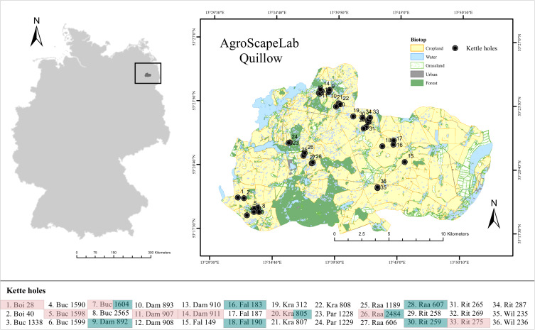

### 2.3. Kettle-hole area and distance matrix

For all kettle holes of the region (i.e., approximately 2000 kettle holes) mapped in 2016 by ‘Amt für Statistik Berlin‐Brandenburg’ (2017), we measured the area using ArcGIS 10 (ESRI 2011) and calculated the pairwise distance with respect to all neighboring kettle holes to estimate the degree of structural connectivity at a landscape level. From a previous study (Lozada-Gobilard et al. 2021a) (Fig. 1, Supplementary material Table S1), we selected 13 kettle holes where *P. australis* and *T. latifolia* were abundant.

### 2.4. Wind speed, seed release height, and terminal velocity

[Seed dispersal](https://www.sciencedirect.com/topics/earth-and-planetary-sciences/seed-dispersal) by wind is determined by both environment and dispersal traits. The most important environmental factor is horizontal wind speed, and the most important dispersal traits are seed release height and terminal velocity (Zhu et al., 2016). Wind speed (m/s) was obtained from an anemometer from a local [weather station](https://www.sciencedirect.com/topics/agricultural-and-biological-sciences/weather-stations) (“Lambrecht Wetterstation”, operated by the local research station of the Leibniz Centre for Agricultural Landscape Research, ZALF, in Dedelow). Wind data had a 10-minute resolution of three consecutive years 2015–2017 for the period between June and October to account for both pollen (between June–July) and seed dispersal (August–October) of *P. australis* and *T. latifolia.* A Weibull distribution was fitted to the wind speed values and used in the seed dispersal simulations (Seguro and Lambert, 2000). In each of the selected kettle holes, height of 30 individuals per species was measured to characterize seed release height. Seed terminal velocity was acquired from the LEDA database (Kleyer et al., 2008) and D3 database (Hintze et al., 2013), which are now integrated into the TRY database (Kattge et al., 2019). These values of seed release height and terminal velocity were fitted to log-normal distributions that were used in the seed dispersal simulations.

### 2.5. Seed dispersal model

Many [mechanistic models](https://www.sciencedirect.com/topics/agricultural-and-biological-sciences/mechanistic-model) for seed dispersal by wind have been developed (Nathan et al., 2011). Despite simplicity of its form, the WALD model (Katul et al., 2005) involves all key parameters determining seed dispersal by wind, and has been widely used in the literature (e.g., Lozada-Gobilard et al., 2020; Wyse et al., 2019). Here, we used the WALD mechanistic model to simulate seed dispersal under alternative landscape scenarios. The kettle holes were mainly surrounded by crops and grassland, and so we carried out three simulation scenarios (“low”, “dynamic”, and “high”) to examine the effects of vegetation height on seed dispersal distance, the probability of long-distance seed dispersal (LDD), and the connectivity among the kettle holes (Table 1). In the “low” scenario, vegetation height was 5 cm for crops and 10 cm for grassland during the dispersal season, while in the “high” scenario, vegetation height was 90 cm for crops and 80 cm for grassland. In the “dynamic” scenario, at any time during the simulation, vegetation height was randomly drawn from a continuous uniform distribution bounded by the extreme values in low and high scenarios, leading to variations in vegetation height in time. These values of vegetation height were selected based on the representative aerodynamic roughness length of cropland and grassland (Hansen, 1993), as well as our field measurements.

Table 1. **Input and output parameters of the simulation model in the three scenarios tested in this study**. Parameters used in the model corresponding to the three different land-use scenarios**.** *U*: horizontal wind speed, *H*: vegetation height, *H*<sub>*r*</sub>: seed release height, *V*<sub>*t*</sub>: seed [terminal velocity](https://www.sciencedirect.com/topics/earth-and-planetary-sciences/terminal-velocity), DD: dispersal distance, LDDP: the probability of long-distance dispersal.

| Scenario | Description | Model input *U* | Model input *H*<sub>*r*</sub>, *V*<sub>*t*</sub> | Model output DD, LDDP |
| --- | --- | --- | --- | --- |
| Low vegetation | 5 cm for cropland, 10 cm for grassland | Weibull distribution of measured values | Lognormal distribution of measured values or from the database LEDA and D3 | Per-seed |
| High vegetation | 90 cm for cropland, 80 cm for grassland |  |  |  |
| Dynamic vegetation | Vegetation height changes dynamically |  |  |  |

A total of 13 kettle holes, (10 kettle holes with either *P. australis* or *T. latifolia* plus 3 with occurrence of both species), were selected as origin where seed dispersal simulations began (Fig. 1), and these origin kettle holes were later used to calculate the connectivity within the complete network of 1923 kettle holes distributed in the study area. In each scenario, if a species was present in an origin kettle hole, then one million seed dispersal events were simulated for that species, and seed dispersal distance and the probability of LDD (i.e., the chance of a seed dispersing further than a pre-defined threshold distance) (Nathan, 2005) were calculated. We estimated the probability of LDD at three threshold distances: 500, 1000, and 2000 m. A previous study in the area identified 500 m as the distance enhancing plant diversity (Lozada-Gobilard et al., 2019). The distance of 1000 m corresponds to the maximum seed dispersal distance previously observed in *P. australis* (Soomers et al., 2013), and the 2000 m distance was included for theoretical comparison (Nathan, 2005). In total, 48 million seed dispersal events were simulated in the study.

### 2.6. Data analysis

Following the principle of Hanski’s Connectivity Index (Hanski and Thomas, 1994), we defined an index to quantify the connectivity between a target kettle hole and the origin kettle holes in a scenario:$Connectivityindex=∑1Nseedsimax(seedslow,i,seedsdynamic,i,seedshigh,i)N$where *N* indicates the total number of origin kettle holes, $seedsi$ indicates the number of seeds that were dispersed to the target kettle from the *i*-th origin kettle hole in the scenario of interest, and $seedslow,i$, $seedsdynamic,i$, and $seedshigh,i$ indicate the numbers of seeds that were dispersed to the target kettle from the *i*-th origin kettle hole in the “low”, “dynamic” and “high” scenarios, respectively. This adapted connectivity index simultaneously quantifies the effects of variation in the number of origin kettle holes that were connected to the target kettle hole, the numbers of seeds that were dispersed from each origin kettle hole to the target kettle hole, and the simulation scenario. The connectivity index ranges from 0 (i.e., when there is no seed from any of the *N* origin kettle holes) to 1 (i.e., when there are seeds from all of the *N* origin kettle holes and the seed number from each origin kettle hole is always the maximum among all the simulation scenarios). The larger the value, the stronger the connectivity.

We applied ANOVA and Tukey's test to compare the connectivity index among different simulation scenarios, using TukeyHSD function in R. Because most of the connectivity index values between the origin and target kettle holes were zero, we only compared positive connectivity values.

## 3. Results

### 3.1. Seed dispersal distance

As expected, in both species, average seed dispersal distance decreased with increasing vegetation height (Fig. 2). In *P. australis* and *T. latifolia*, median dispersal distance was 5-fold and 6-fold higher when vegetation was low as compared to high vegetation, respectively. Mean seed dispersal distance was 2-fold higher with low as compared to high vegetation in both species (Supplementary material Table S2).

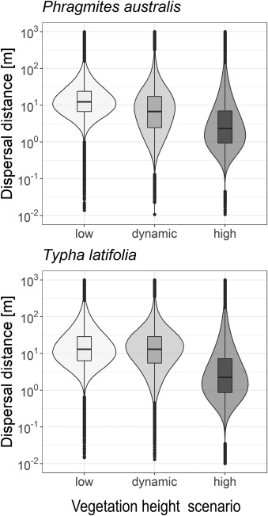

Fig. 2. Variation in seed dispersal distance in various scenarios of simulation. Low: vegetation height was 5 cm for crops and 10 cm for grassland; dynamic: vegetation height varied dynamically during the dispersal season; high: vegetation height was 90 cm for crops and 80 cm for grassland.

### 3.2. Probability of long-distance seed dispersal (LDD)

In contrast to mean dispersal distance, probability of LDD increased with vegetation height for both species (Fig. 3). When the threshold distance was 500 m, high vegetation led to 7-fold (*P. australis*) and 1.5-fold (*T. latifolia*) larger mean probability of LDD than low vegetation. At a threshold distance of 1000 m, mean probability of LDD under high vegetation scenario was 27-fold higher for *P. australis* and 3-fold for *T. latifolia* compared to low vegetation. At a threshold distance of 2000 m, mean probability of LDD under high vegetation scenario was 7-fold and 9-fold larger than the low vegetation scenario in *P. australis* and *T. latifolia*, respectively (Supplementary material Table S3).

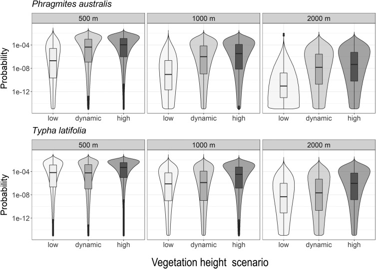

Fig. 3. Probability of long-distance seed dispersal with different threshold distances and in various scenarios of simulation. Low: vegetation height was 5 cm for crops and 10 cm for grassland; dynamic: vegetation height varied dynamically during the dispersal season; high: vegetation height was 90 cm for crops and 80 cm for grassland.

### 3.3. Connectivity index

Overall, the connectivity index was zero for 98% of the 1923 kettle holes. Both the proportion of kettle holes that were connected to the origin kettle holes and the connectivity increased with vegetation height. For *P. australis*, in the “low”, “dynamic”, and “high” scenarios, 1.5%, 1.7%, and 1.8% of the kettle holes were connected with the origin kettle holes, and the connectivity index (Mean ± SD) was 0.06 ± 0.04, 0.16 ± 0.09 and 0.24 ± 0.12, respectively. For *T. latifolia*, in the “low”, “dynamic” and “high” scenarios, 1.6%, 1.5% and 1.7% of the kettle holes were connected with the origin kettle holes, and the connectivity index (Mean ± SD) was 0.17 ± 0.08, 0.17 ± 0.1 and 0.30 ± 0.1, respectively (Fig. 4). Connectivity index significantly differed in: *P. australis* (F<sub>2,5766</sub> = 8.05, p = <0.0001) and *T. latifolia* (F<sub>2,5766</sub> = 4.74, p = 0.008) with significantly higher connectivity index in the “high” compared to the “low” scenario in both species (Tukey test: *P. autralis* p = 0.02, *T. latifolia* p < 0.001) (Fig. 4). The “dynamic” scenario differed significantly from the “low” scenario in *P. australis*; while in *T. latifolia* the “dynamic” scenario differed significantly from the “high” scenario (Fig. 4).

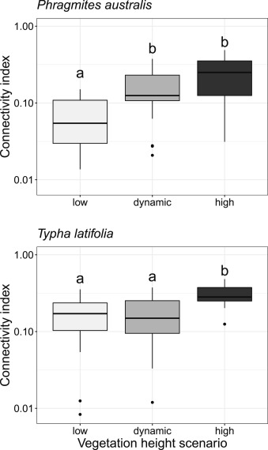

Fig. 4. Variation in connectivity index in various scenarios of simulation. Low: vegetation height was 5 cm for crops and 10 cm for grassland; dynamic: vegetation height varied dynamically during the dispersal season; high: vegetation height was 90 cm for crops and 80 cm for grassland.

## 4. Discussion

In the present study, we evaluated the effect of surrounding vegetation height on seed dispersal in two wind-dispersed species: *Phragmites australis* and *Typha latifolia,* both occurring in local populations in kettle holes that are embedded in an agricultural landscape. Our results show that mean seed dispersal distance decreases with vegetation height, but the probability of long-distance seed dispersal (LDD) increases with vegetation height. This novel and surprising result suggests a trade-off between mean dispersal distance and LDD, and this trade-off, which impacts connectivity, is dependent on vegetation height.

The way in which LDD responds to surrounding vegetation height has been seldom studied at the landscape scale. We hypothesized that low surrounding vegetation would increase seed dispersal and thus connectivity of the kettle holes. Indeed, our finding shows that mean seed dispersal distance decreases with increasing vegetation height. This finding is supported by empirical evidence (Marushia and Holt, 2006, Soons et al., 2004, Zhu et al., 2016) and can be derived from dispersal mechanisms (Nathan et al., 2011). High vegetation limits mean dispersal distance because aerodynamic roughness length increases with vegetation height, which reduces the wind speed that a flying seed experiences. In addition, high vegetation reduces the effective seed release height (i.e., difference between seed release height and vegetation height) (Bohrer et al., 2008), leading to shorter flying time of seeds in the air.

In contrast with our expectations, the connectivity of the kettle holes did not decrease but rather increased with vegetation height. This was mainly because the probability of LDD increased with vegetation height, which is caused by increased turbulence due to increased vegetation height (Katul et al., 2005, Nathan et al., 2002, Soons et al., 2004). In summary, vegetation height, together with seed release height, determines the wind speed of a flying seed, the miminal falling time, and the turbulence, and hence, the probability of uplifting, which strongly affects the probability of LDD (Soons et al., 2004). Therefore, our finding highlights the importance of the rare LDD events, rather than many short-distance dispersal events, to enhance the degree of connectivity between kettle holes.

### 4.1. LDD events and seed establishment are both important to promote connectivity

Plant functional connectivity is defined as the effective dispersal of propagules among [fragmented habitats](https://www.sciencedirect.com/topics/agricultural-and-biological-sciences/forest-fragmentation), which is not only determined by the landscape structure but also depends on interactions between plants and their environment (i.e., abiotic and biotic factors), including dispersal vectors and establishment of individuals in the new patches (Auffret et al., 2017). Wind-dispersed species are more resilient to habitat fragmentation mainly due to the independence of the agent (i.e. wind) to the habitat; while animal-dispersed species highly depend on the active movement of their agent (i.e. animals) which is negatively affected by habitat loss (Herrmann et al., 2016). These interactions can change in time and space, determining dispersal ranges from short to extreme long-distances (Treep et al., 2021). In addition, high variation of dispersal-related traits at a plant level, can cause different responses across different ecological scales (Chen et al., 2020).

LDD events are essential for colonization of far new suitable habitats, playing an important role in connectivity and conservation (Trakhtenbrot et al., 2005). However, post-dispersal processes related to density-dependent mortality as a result of predation or competition will finally determine whether a seed will successfully establish in a particular site (Nathan and Muller-Landau, 2000). Indeed, it has been observed in kettle holes that a combination of abiotic filters (density of the kettle holes, patch area), biotic filters (pollinators, competition), and seed longevity and dispersal traits (clonal growth) influences assembly and dynamics of plant communities (Lozada-Gobilard et al., 2019, Schöpke et al., 2019).

[Seedling establishment](https://www.sciencedirect.com/topics/earth-and-planetary-sciences/seedling-establishment) depends on successful [seed germination](https://www.sciencedirect.com/topics/agricultural-and-biological-sciences/seed-germination). In wetlands, seed germination might occur rarely, because many [aquatic species](https://www.sciencedirect.com/topics/agricultural-and-biological-sciences/aquatic-species), such as *P. australis* and *T. latifolia*, expand their populations mainly via clonal reproduction, rapidly occupying the entire wetland habitat (Barrett et al., 1993, Packer et al., 2017). As a result, seedling establishment of *P. australis* and *T. latifolia* mainly depend on the availability of suitable patches, competition, as well as water level and the area of the riparian zonation (Coops and van der Velde, 1995). Despite their fast clonal expansion and its potential negative effects in recruitment and establishment of the study species, seed germination does occur. A combination of LDD events mediated by wind, and passive dispersal of seeds by water-birds both, internal (endozoochory) and external (ectozoochory) (Figuerola and Green, 2002), might increase the chance of germination and seedling establishment in suitable kettle holes. Further research on seed germination of the study species in kettle holes could provide important insights on seedling establishment of wind-dispersed species in agricultural ecosystems.

### 4.2. Agricultural management can change landscape connectivity patterns

Our study showed that the probability of LDD is affected by vegetation height. These results indicate that the land-use management can potentially change the dispersal patterns of these species and other wind-dispersed [plant species](https://www.sciencedirect.com/topics/earth-and-planetary-sciences/plant-specie) occurring in isolated habitat patches. Our results show the highest probability of LDD and highest connectivity under a high vegetation scenario. Therefore, types and sizes of croplands, mowing frequency of grasslands and rotation of crops (i.e., varying in height), could affect the potential dispersal and the connectivity among kettle holes at a landscape level.

Higher probability of LDD under the high vegetation scenario suggests that the management of the agricultural matrix influences the degree of connectivity among kettle holes. Our results indicate that to keep a dynamic connectivity of wind-dispersed species, LDD events should happen and they depend on the vegetation of the surrounding cropland, which depends on the management of the [agroecosystem](https://www.sciencedirect.com/topics/agricultural-and-biological-sciences/agroecosystems). It is likely that more homogenous landscapes, larger field sizes, as well as unfavorable timing and increased synchronicity of mowing and harvesting would decrease LDD events, and therefore reduce the connectivity of the entire landscape. Nevertheless, more studies and models are needed to better understand these spatiotemporal dynamics and their resilience to agricultural and climate pressures.

The connectivity change depending on vegetation height presented in this study indicates the vulnerability of these wetland ecosystems. Farmers benefit from many ecosystem services provided by the kettle holes, including water supply, diversity nursery (Vasić et al., 2020), and as shelter for [pollinators](https://www.sciencedirect.com/topics/earth-and-planetary-sciences/pollinator) (Lozada-Gobilard et al., 2021a). These advantages are provided without any yield loss associated to these habitat patches (Raatz et al., 2019). Due to these services provided by kettle holes, it is crucial that farmers have awareness and commitment to their conservation and appropriate management (Dale et al., 2005).

### 4.3. Possible negative effects of connectivity?

High connectivity is usually associated with positive effects, but it can also enhance the spread of [invasive species](https://www.sciencedirect.com/topics/earth-and-planetary-sciences/invasive-species) (e.g., Thomas and Moloney, 2013). Higher connectivity is typically associated with positive effects of reducing risks of inbreeding, lowering the probability of [local extinctions](https://www.sciencedirect.com/topics/earth-and-planetary-sciences/local-extinction) and increasing gene flow and diversity among populations (Leimu et al., 2006). Both of our study species are native to Europe, but *P. australis* genotypes from Europe became invasive in many areas of the USA and Australia, and some degree of invasiveness was also reported for *T. latifolia* (Gucker, 2008). Preliminary observations showed a decrease in plant and bee species diversity in those kettle holes dominated by *P. australis*, *T. latifolia* and other reed species (e.g., *[Phalaris arundinacea](https://www.sciencedirect.com/topics/agricultural-and-biological-sciences/phalaris-arundinacea)**, Calmagrostis canescens, C. epigejos, Sparganium erectum*) (Supplementary material Fig. S1, Table S4, Lozada-Gobilard, 2019); however, these results correspond to a reduced number of observations in time and space. More research is needed to confirm these negative tendencies and to implement a proper management to reduce spread of potential invasive wind-dispersed species. For example, one way could be to keep certain height of stubble after crop harvesting in areas downwind to reduce mean seed dispersal among the kettle holes.

## 5. Conclusion

Our study shows that mean dispersal distance decreases with increasing vegetation height in surrounding matrix vegetation. However, counter-intuitively, the probability of long-distance seed dispersal (LDD) increases with vegetation height and connectivity among kettle holes is largely determined by the events of LDD. Indeed, vegetation cover has important effects on seed dispersal by wind (Bullock and Moy, 2004, Mcevoy and Cox, 1987), and increased vegetation height has been shown to supress dispersal of invasive species (Davies and Sheley, 2007, Marushia and Holt, 2006). Therefore, appropriate management of crop height in downwind areas could both reduce mean seed dispersal of undesired wind-dispersed plants among kettle holes or enhance functional connectivity among them. The observed positive effect of vegetation height on the probability of LDD and its impact on connectivity provide novel insights into landscape level (meta-) community dynamics — a change in matrix vegetation height by land-use or environmental changes could strongly affect the spread and connectivity of wind-dispersed plants. To reduce the invasion risk of alien species or to maintain (meta-) population and (meta-) community connectivity on these agricultural ecosystems, one should specifically consider this opposite effect of vegetation height on mean seed dispersal distance and the probability of LDD.

## Authors' contributions

**SLG** and **JZ** designed the study. **SLG** collected the data in the field and **JZ** ran the simulations. **SLG** and **JZ** analyzed the data. **SLG**, **FJ** and **JZ** discussed the results, wrote the paper, contributed critically to the drafts, and gave final approval for publication.

## Declaration of Competing Interest

The authors declare that they have no known competing financial interests or personal relationships that could have appeared to influence the work reported in this paper.

## Acknowledgments

We would like to thank Gernot Verch and Joerg Haase for providing wind data, the Leibniz Centre for Agricultural Landscape Research, ZALF, in Dedelow for providing facilities for the work in the field and to the BioMove Research training group for their valuable support. We thank Larissa Raatz for providing important information about the vegetation height surrounding the kettle holes and Michelle Talal for proofreading the text. SLG and FJ thank Deutsche Forschungsgemeinschaft (DFG) [DFG-GRK 2118/1] and JZ the Sino-German (CSC-DAAD) Postdoc Scholarship Program [57165010] for funding.

## Appendix A. Supplementary material

[Download : Download Acrobat PDF file (526KB)](https://ars.els-cdn.com/content/image/1-s2.0-S0167880921003820-mmc1.pdf)

Supplementary material.

.

## Data availability

All data and code are currently archived at the Leibniz Centre for Agricultural Landscape Research, ZALF, and the Institute of Landscape and Plant Ecology, University of Hohenheim, and will become publicly available after the manuscript is accepted for publication.

## References

**Aavik et al., 2014**

T. Aavik, R. Holderegger, J. Bolliger

**The structural and functional connectivity of the grassland plant Lychnis flos-cuculi**

Hered. (Edinb.), 112 (2014), pp. 471-478, 10.1038/hdy.2013.120

[View Record in Scopus](https://www.scopus.com/inward/record.url?eid=2-s2.0-84899431846&partnerID=10&rel=R3.0.0)Google Scholar

**Auffret et al., 2017**

A.G. Auffret, Y. Rico, J.M. Bullock, D.A.P. Hooftman, A. Traveset, R.J. Pakeman, M.B. Soons, A. Su, H.H. Wagner, S.A.O. Cousins

**Plant functional connectivity – integrating landscape structure and effective dispersal**

J. Ecol., 105 (2017), pp. 1648-1656, 10.1111/1365-2745.12742

[View Record in Scopus](https://www.scopus.com/inward/record.url?eid=2-s2.0-85013866106&partnerID=10&rel=R3.0.0)[Google Scholar](https://scholar.google.com/scholar?q=Plant%20functional%20connectivity%20%20integrating%20landscape%20structure%20and%20effective%20dispersal)

**Barrett et al., 1993**

S.C.H. Barrett, C.G. Eckert, B.C. Husband

**Evolutionary processes in aquatic plant populations**

Aquat. Bot., 44 (1993), pp. 105-145, 10.1016/0304-3770(93)90068-8

[Article](https://www.sciencedirect.com/science/article/pii/0304377093900688)[Download PDF](https://www.sciencedirect.com/science/article/pii/0304377093900688/pdf?md5=7072646fa5eccff2c3797b496fc858a9&pid=1-s2.0-0304377093900688-main.pdf)[View Record in Scopus](https://www.scopus.com/inward/record.url?eid=2-s2.0-0027845964&partnerID=10&rel=R3.0.0)[Google Scholar](https://scholar.google.com/scholar_lookup?title=Evolutionary%20processes%20in%20aquatic%20plant%20populations&publication_year=1993&author=S.C.H.%20Barrett&author=C.G.%20Eckert&author=B.C.%20Husband)

**Bohrer et al., 2008**

G. Bohrer, G.G. Katul, R. Nathan, R.L. Walko, R. Avissar

**Effects of canopy heterogeneity, seed abscission and inertia on wind-driven dispersal kernels of tree seeds**

J. Ecol., 96 (2008), pp. 569-580, 10.1111/j.1365-2745.2008.01368.x

[View Record in Scopus](https://www.scopus.com/inward/record.url?eid=2-s2.0-44949185778&partnerID=10&rel=R3.0.0)Google Scholar

**Brose, 2001**

U. Brose

**Relative importance of isolation, area and habitat heterogeneity for vascular plant species richness of temporary wetlands in east-German farmland**

Ecography, 24 (2001), pp. 722-730, 10.1111/j.1600-0587.2001.tb00533.x

Google Scholar

**Bullock and Moy, 2004**

J.M. Bullock, I.L. Moy

**Plants as seed traps: inter-specific interference with dispersal**

Acta Oecologica, 25 (2004), pp. 35-41, 10.1016/j.actao.2003.10.005

[Article](https://www.sciencedirect.com/science/article/pii/S1146609X03001152)[Download PDF](https://www.sciencedirect.com/science/article/pii/S1146609X03001152/pdfft?md5=1f34ab2cb74da4d4b7719e5cf7f949e9&pid=1-s2.0-S1146609X03001152-main.pdf)[View Record in Scopus](https://www.scopus.com/inward/record.url?eid=2-s2.0-1542379703&partnerID=10&rel=R3.0.0)[Google Scholar](https://scholar.google.com/scholar_lookup?title=Plants%20as%20seed%20traps%3A%20inter-specific%20interference%20with%20dispersal&publication_year=2004&author=J.M.%20Bullock&author=I.L.%20Moy)

**Campbell et al., 1998**

Campbell, S. Gaylon, J. Norman

**An Introduction to Environmental Biophysics**

Springer-Verlag, New York (1998)

[Google Scholar](https://scholar.google.com/scholar_lookup?title=An%20Introduction%20to%20Environmental%20Biophysics&publication_year=1998&author=Campbell&author=S.%20Gaylon&author=J.%20Norman)

**Céréghino et al., 2008**

R. Céréghino, J. Biggs, B. Oertli, S. Declerck

**The ecology of European ponds: defining the characteristics of a neglected freshwater habitat**

Hydrobiologia, 597 (2008), pp. 1-6, 10.1007/s10750-007-9225-8

Google Scholar

**Céréghino et al., 2012**

R. Céréghino, B. Oertli, M. Bazzanti, C. Coccia, A. Compin, J. Biggs, N. Bressi, P. Grillas, A. Hull, T. Kalettka, O. Scher

**Biological traits of European pond macroinvertebrates**

Hydrobiologia, 689 (2012), pp. 51-61, 10.1007/s10750-011-0744-y

[View Record in Scopus](https://www.scopus.com/inward/record.url?eid=2-s2.0-84860580877&partnerID=10&rel=R3.0.0)Google Scholar

**Champion et al., 2007**

P.D. Champion, D.E. Hofstra, J.S. Clayton

**Border control for potential aquatic weeds. Stage 3. Weed risk management**

Sci. Conserv., 271 (2007), pp. 1-41

[View Record in Scopus](https://www.scopus.com/inward/record.url?eid=2-s2.0-34248682679&partnerID=10&rel=R3.0.0)Google Scholar

**Chen et al., 2020**

S.C. Chen, E. Dener, A. Altman, F. Chen, I. Giladi

**Effect of habitat fragmentation on seed dispersal ability of a wind-dispersed annual in an agroecosystem**

Agric. Ecosyst. Environ. (2020), p. 304, 10.1016/j.agee.2020.107138

Google Scholar

**Ciotir et al., 2017**

C. Ciotir, J. Szabo, J. Freeland

**Genetic characterization of cattail species and hybrids (Typha spp.) in Europe**

Aquat. Bot., 141 (2017), pp. 51-59, 10.1016/j.aquabot.2017.03.005

[Article](https://www.sciencedirect.com/science/article/pii/S0304377017300943)[Download PDF](https://www.sciencedirect.com/science/article/pii/S0304377017300943/pdfft?md5=fde8b2a2228d733a05c0ab0e02caf42f&pid=1-s2.0-S0304377017300943-main.pdf)[View Record in Scopus](https://www.scopus.com/inward/record.url?eid=2-s2.0-85016428910&partnerID=10&rel=R3.0.0)[Google Scholar](https://scholar.google.com/scholar?q=Genetic%20characterization%20of%20cattail%20species%20and%20hybrids%20%20in%20Europe)

**Coops and van der Velde, 1995**

H. Coops, G. van der Velde

**Seed dispersal, germination and seedling growth of six helophyte species in relation to water‐level zonation**

Freshw. Biol., 34 (1995), pp. 13-20, 10.1111/j.1365-2427.1995.tb00418.x

[View Record in Scopus](https://www.scopus.com/inward/record.url?eid=2-s2.0-0028983497&partnerID=10&rel=R3.0.0)[Google Scholar](https://scholar.google.com/scholar?q=Seed%20dispersal,%20germination%20and%20seedling%20growth%20of%20six%20helophyte%20species%20in%20relation%20to%20waterlevel%20zonation)

**Dale et al., 2005**

V. Dale, S. Archer, M. Chang, D. Ojima

**Ecological impacts and mitigation strategies for rural land management**

Ecol. Appl., 15 (2005), pp. 1879-1892, 10.1890/03-5330

[View Record in Scopus](https://www.scopus.com/inward/record.url?eid=2-s2.0-30844474188&partnerID=10&rel=R3.0.0)Google Scholar

**Davies and Sheley, 2007**

K.W. Davies, R.L. Sheley

**Influence of neighboring vegetation height on seed dispersal: implications for invasive plant management**

Weed Sci., 55 (2007), pp. 626-630, 10.1614/ws-07-067.1

[View Record in Scopus](https://www.scopus.com/inward/record.url?eid=2-s2.0-36549032234&partnerID=10&rel=R3.0.0)Google Scholar

**De Meester et al., 2005**

L. De Meester, S. Declerck, R. Stoks, G. Louette, F. van de Meutter, T. De Bie, E. Michels, L. Brendonck

**Ponds and pools as model systems in conservation biology, ecology and evolutionary biology**

Aquat. Conserv. Mar. Freshw. Ecosyst., 15 (2005), pp. 715-725, 10.1002/aqc.748

[View Record in Scopus](https://www.scopus.com/inward/record.url?eid=2-s2.0-28144433128&partnerID=10&rel=R3.0.0)Google Scholar

**Figuerola and Green, 2002**

J. Figuerola, A.J. Green

**Dispersal of aquatic organisms by waterbirds: a review of past research and priorities for future studies**

Freshw. Biol., 47 (2002), pp. 483-494, 10.1046/j.1365-2427.2002.00829.x

[View Record in Scopus](https://www.scopus.com/inward/record.url?eid=2-s2.0-0036198842&partnerID=10&rel=R3.0.0)Google Scholar

**Gucker, 2008**

Gucker, C., 2008. Typha latifolia. In: Fire Effects Information System [Online]. U.S. Dep. Agric. For. Serv. Rocky Mt. Res. Station. Fire Sci. Lab.

Google Scholar

**Hansen, 1993**

Hansen, F.V., 1993. Surface Roughness Lengths. ARL.

[Google Scholar](https://scholar.google.com/scholar?q=Hansen,%20F.V.,%201993.%20Surface%20Roughness%20Lengths.%20ARL.)

**Hanski and Thomas, 1994**

I. Hanski, C.D. Thomas

**Metapopulation dynamics and conservation: a spatially explicit model applied to butterflies**

Biol. Conserv., 68 (1994), pp. 167-180

[Article](https://www.sciencedirect.com/science/article/pii/0006320794903484)[Download PDF](https://www.sciencedirect.com/science/article/pii/0006320794903484/pdf?md5=7798ecb3da279e6a1ee139e7ce137b12&pid=1-s2.0-0006320794903484-main.pdf)[View Record in Scopus](https://www.scopus.com/inward/record.url?eid=2-s2.0-0028174966&partnerID=10&rel=R3.0.0)Google Scholar

**Harmon-Threatt et al., 2009**

A.N. Harmon-Threatt, J.H. Burns, L.A. Shemyakina, T.M. Knight

**Breeding system and pollination ecology of introduced plants compared to their native relatives**

Am. J. Bot., 96 (2009), pp. 1544-1550, 10.3732/ajb.0800369

[View Record in Scopus](https://www.scopus.com/inward/record.url?eid=2-s2.0-69249216555&partnerID=10&rel=R3.0.0)Google Scholar

**Herrmann et al., 2016**

J.D. Herrmann, T.A. Carlo, L.A. Brudvig, E.I. Damschen, N.M. Haddad, D.J. Levey, J.L. Orrock, J.J. Tewksbury

**Connectivity from a different perspective: comparing seed dispersal kernels in connected vs. unfragmented landscapes**

Ecology, 97 (2016), pp. 1274-1282, 10.1890/15-0734.1

[View Record in Scopus](https://www.scopus.com/inward/record.url?eid=2-s2.0-85047290305&partnerID=10&rel=R3.0.0)Google Scholar

**Hintze et al., 2013**

C. Hintze, F. Heydel, C. Hoppe, S. Cunze, A. König, O. Tackenberg

**D3: The Dispersal and Diaspore Database - Baseline data and statistics on seed dispersal**

Perspect. Plant Ecol. Evol. Syst., 15 (2013), pp. 180-192, 10.1016/j.ppees.2013.02.001

[Article](https://www.sciencedirect.com/science/article/pii/S1433831913000218)[Download PDF](https://www.sciencedirect.com/science/article/pii/S1433831913000218/pdfft?md5=c190d842ef855e6a995ecb99d734adfc&pid=1-s2.0-S1433831913000218-main.pdf)[View Record in Scopus](https://www.scopus.com/inward/record.url?eid=2-s2.0-84876869198&partnerID=10&rel=R3.0.0)Google Scholar

**Kalettka and Rudat, 2006**

T. Kalettka, C. Rudat

**Hydrogeomorphic types of glacially created kettle holes in North-East Germany**

Limnologica, 36 (2006), pp. 54-64, 10.1016/j.limno.2005.11.001

[Article](https://www.sciencedirect.com/science/article/pii/S0075951105000824)[Download PDF](https://www.sciencedirect.com/science/article/pii/S0075951105000824/pdfft?md5=8ef121014dc494101707f41327b422f3&pid=1-s2.0-S0075951105000824-main.pdf)[View Record in Scopus](https://www.scopus.com/inward/record.url?eid=2-s2.0-33644777448&partnerID=10&rel=R3.0.0)[Google Scholar](https://scholar.google.com/scholar_lookup?title=Hydrogeomorphic%20types%20of%20glacially%20created%20kettle%20holes%20in%20North-East%20Germany&publication_year=2006&author=T.%20Kalettka&author=C.%20Rudat)

**Kalettka et al., 2001**

T. Kalettka, C. Rudat, J. Quast

**Potholes in northeast German agro-landscapes: functions, land use impacts, and protection strategies**

J.D. Tenhunen, R. Lenz, R. Hantschel (Eds.), Ecosystem Approaches to Landscape Management in Central Europe, Ecological Studies, Springer (2001), pp. 291-298

[CrossRef](https://doi.org/10.1007/978-3-662-04504-6_18)[View Record in Scopus](https://www.scopus.com/inward/record.url?eid=2-s2.0-0141525625&partnerID=10&rel=R3.0.0)Google Scholar

**Kattge et al., 2019**

J. Kattge, G. Bönisch, S. Díaz, S. Lavorel, I.C. Prentice, P. Leadley, S. Tautenhahn, G. Werner, E. Al

**TRY plant trait database – enhanced coverage and open access**

Glob. Chang. Biol., 26 (2019), pp. 119-188, 10.1111/gcb.14904

[Google Scholar](https://scholar.google.com/scholar?q=TRY%20plant%20trait%20database%20%20enhanced%20coverage%20and%20open%20access)

**Katul et al., 2005**

G.G. Katul, A. Porporato, R. Nathan, M. Siqueira, M.B. Soons, D. Poggi, H.S. Horn, S.A. Levin

**Mechanistic analytical models for long-distance seed dispersal by wind**

Am. Nat., 166 (2005), pp. 368-381

[View Record in Scopus](https://www.scopus.com/inward/record.url?eid=2-s2.0-24644460572&partnerID=10&rel=R3.0.0)Google Scholar

**Kleyer et al., 2008**

M. Kleyer, R.M. Bekker, I.C. Knevel, J.P. Bakker, K. Thompson, M. Sonnenschein, P. Poschlod, J.M. Van Groenendael, L. Klimeš, J. Klimešová, S. Klotz, G.M. Rusch, M. Hermy, D. Adriaens, G. Boedeltje, B. Bossuyt, A. Dannemann, P. Endels, L. Götzenberger, J.G. Hodgson, A.K. Jackel, I. Kühn, D. Kunzmann, W.A. Ozinga, C. Römermann, M. Stadler, J. Schlegelmilch, H.J. Steendam, O. Tackenberg, B. Wilmann, J.H.C.C. Cornelissen, O. Eriksson, E. Garnier, B. Peco, J.M.Van Groenendael, L. Klime, J. Klime, S. Klotz, G.M. Rusch, M. Hermy, D. Adriaens, G. Boedeltje, B. Bossuyt, A. Dannemann, L. Götzenberger, J.G. Hodgson, A.K. Jackel, I. Kühn, D. Kunzmann, W.A. Ozinga, C. Römermann, M. Stadler, J. Schlegelmilch, H.J. Steendam, O. Tackenberg, B. Wilmann, J.H.C.C. Cornelissen, O. Eriksson, E. Garnier, B. Peco

**The LEDA traitbase: a database of life-history traits of the Northwest European flora**

J. Ecol., 96 (2008), pp. 1266-1274, 10.1111/j.1365-2745.2008.01430.x

[View Record in Scopus](https://www.scopus.com/inward/record.url?eid=2-s2.0-54049129363&partnerID=10&rel=R3.0.0)Google Scholar

**Kühn et al., 2004**

I. Kühn, W. Durka, S. Klotz

**BiolFlor — a new plant-trait database as a tool for plant invasion ecology**

Divers Distrib., 10 (2004), pp. 363-365

[View Record in Scopus](https://www.scopus.com/inward/record.url?eid=2-s2.0-4644268832&partnerID=10&rel=R3.0.0)[Google Scholar](https://scholar.google.com/scholar?q=BiolFlor%20%20a%20new%20plant-trait%20database%20as%20a%20tool%20for%20plant%20invasion%20ecology)

**Leibold et al., 2004**

M.A. Leibold, M. Holyoak, N. Mouquet, P. Amarasekare, J.M. Chase, M.F. Hoopes, R.D. Holt, J.B. Shurin, R. Law, D. Tilman, M. Loreau, A. Gonzalez

**The metacommunity concept: a framework for multi-scale community ecology**

Ecol. Lett., 7 (2004), pp. 601-613, 10.1111/j.1461-0248.2004.00608.x

Google Scholar

**Leimu et al., 2006**

R. Leimu, P. Mutikainen, J. Koricheva, M. Fischer

**How general are positive relationships between plant population size, fitness and genetic variation?**

J. Ecol., 94 (2006), pp. 942-952, 10.1111/j.1365-2745.2006.01150.x

[View Record in Scopus](https://www.scopus.com/inward/record.url?eid=2-s2.0-33746774404&partnerID=10&rel=R3.0.0)[Google Scholar](https://scholar.google.com/scholar?q=How%20general%20are%20positive%20relationships%20between%20plant%20population%20size,%20fitness%20and%20genetic%20variation)

**Lischeid et al., 2018**

G. Lischeid, T. Kalettka, M. Holländer, J. Steidl, C. Merz, R. Dannowski, T. Hohenbrink, C. Lehr, G. Onandia, F. Reverey, M. Pätzig

**Natural ponds in an agricultural landscape: external drivers, internal processes, and the role of the terrestrial-aquatic interface**

Limnologica, 68 (2018), pp. 5-16, 10.1016/j.limno.2017.01.003

[Article](https://www.sciencedirect.com/science/article/pii/S0075951116300524)[Download PDF](https://www.sciencedirect.com/science/article/pii/S0075951116300524/pdfft?md5=aa34c5d815669b49171a9fae78565d9c&pid=1-s2.0-S0075951116300524-main.pdf)[View Record in Scopus](https://www.scopus.com/inward/record.url?eid=2-s2.0-85013465922&partnerID=10&rel=R3.0.0)Google Scholar

**Logue et al., 2011**

J.B. Logue, N. Mouquet, H. Peter, H. Hillebrand

**Empirical approaches to metacommunities: a review and comparison with theory**

Trends Ecol. Evol., 26 (2011), pp. 482-491, 10.1016/j.tree.2011.04.009

[Article](https://www.sciencedirect.com/science/article/pii/S0169534711001315)[Download PDF](https://www.sciencedirect.com/science/article/pii/S0169534711001315/pdfft?md5=32a464610449750bbc7c2d26bfb37ef4&pid=1-s2.0-S0169534711001315-main.pdf)[View Record in Scopus](https://www.scopus.com/inward/record.url?eid=2-s2.0-80051471111&partnerID=10&rel=R3.0.0)Google Scholar

**Lozada-Gobilard, 2019**

Lozada-Gobilard, S., 2019. From genes to communities: Assessing plant diversity and connectivity in kettle holes as metaecosystems in agricultural landscapes. Phd Thesis. University of Potsdam. 147 p.

Google Scholar

**Lozada-Gobilard et al., 2021a**

S. Lozada-Gobilard, C.M. Landivar Albis, K.B. Rupik, M. Pätzig, S. Hausmann, R. Tiedemann, J. Joshi

**Habitat quality and connectivity in kettle holes enhance bee diversity in agricultural landscapes**

Agric. Ecosyst. Environ., 319 (2021), pp. 0-3, 10.1016/j.agee.2021.107525

Google Scholar

**Lozada-Gobilard et al., 2020**

S. Lozada-Gobilard, H. Pánková, J. Zhu, B. Stojanova, Z. Münzbergov

**Potential risk of interspecific hybridization in ex situ collections**

J. Nat. Conserv. (2020), p. 58, 10.1016/j.jnc.2020.125912

Google Scholar

**Lozada-Gobilard et al., 2021b**

S. Lozada-Gobilard, C. Schwarzer, R. Dyer, R. Tiedemann, J. Joshi

**Genetic diversity and connectivity in plant species differing in clonality and dispersal mechanisms in wetland Island Habitats**

J. Hered. (2021), pp. 1-14, 10.1093/jhered/esaa059

Google Scholar

**Lozada-Gobilard et al., 2019**

S. Lozada-Gobilard, S. Stang, K. Pirhofer-Walzl, T. Kalettka, T. Heinken, B. Schröder, J. Eccard, J. Joshi

**Environmental filtering predicts plant-community trait distribution and diversity: kettle holes as models of meta-community systems**

Ecol. Evol., 9 (2019), pp. 1898-1910, 10.1002/ece3.4883

[View Record in Scopus](https://www.scopus.com/inward/record.url?eid=2-s2.0-85062093989&partnerID=10&rel=R3.0.0)Google Scholar

**Maheu-Giroux and De Blois, 2007**

M. Maheu-Giroux, S. De Blois

**Landscape ecology of Phragmites australis invasion in networks of linear wetlands**

Landsc. Ecol., 22 (2007), pp. 285-301, 10.1007/s10980-006-9024-z

[View Record in Scopus](https://www.scopus.com/inward/record.url?eid=2-s2.0-33846574180&partnerID=10&rel=R3.0.0)Google Scholar

**Marushia and Holt, 2006**

R.G. Marushia, J.S. Holt

**The effects of habitat on dispersal patterns of an invasive thistle, Cynara cardunculus**

Biol. Invasions, 8 (2006), pp. 577-594, 10.1007/s10530-005-1601-6

[View Record in Scopus](https://www.scopus.com/inward/record.url?eid=2-s2.0-33745658490&partnerID=10&rel=R3.0.0)Google Scholar

**Mcevoy and Cox, 1987**

P.B. Mcevoy, C.S. Cox

**Wind dispersal distances in dimorphic achenes of Ragwort, Senecio Jacobaea**

Ecology, 68 (1987), pp. 2006-2015

[CrossRef](https://doi.org/10.2307/1939891)[View Record in Scopus](https://www.scopus.com/inward/record.url?eid=2-s2.0-0023511197&partnerID=10&rel=R3.0.0)[Google Scholar](https://scholar.google.com/scholar_lookup?title=Wind%20dispersal%20distances%20in%20dimorphic%20achenes%20of%20Ragwort%2C%20Senecio%20Jacobaea&publication_year=1987&author=P.B.%20Mcevoy&author=C.S.%20Cox)

**Nathan, 2005**

R. Nathan

**Long-distance dispersal research: Building a network of yellow brick roads**

Divers. Distrib., 11 (2005), pp. 125-130, 10.1111/j.1366-9516.2005.00159.x

[View Record in Scopus](https://www.scopus.com/inward/record.url?eid=2-s2.0-15944371948&partnerID=10&rel=R3.0.0)[Google Scholar](https://scholar.google.com/scholar_lookup?title=Long-distance%20dispersal%20research%3A%20Building%20a%20network%20of%20yellow%20brick%20roads&publication_year=2005&author=R.%20Nathan)

**Nathan et al., 2011**

R. Nathan, G.G. Katul, G. Bohrer, A. Kuparinen, M.B. Soons, S.E. Thompson, A. Trakhtenbrot, H.S. Horn

**Mechanistic models of seed dispersal by wind**

Theor. Ecol., 4 (2011), pp. 113-132, 10.1007/s12080-011-0115-3

[View Record in Scopus](https://www.scopus.com/inward/record.url?eid=2-s2.0-79954689611&partnerID=10&rel=R3.0.0)Google Scholar

**Nathan et al., 2002**

R. Nathan, G.G. Katul, H.S. Horn, S.M. Thomas, R. Oren, R. Avissar, S.W. Pacala, S.A. Levin

**Mechanisms of long-distance dispersal of seeds by wind**

Nature, 418 (2002), pp. 409-413, 10.1038/nature00844

[View Record in Scopus](https://www.scopus.com/inward/record.url?eid=2-s2.0-0037173645&partnerID=10&rel=R3.0.0)Google Scholar

**Nathan and Muller-Landau, 2000**

R. Nathan, H.C. Muller-Landau

**Spatial patterns of seed dispersal, their determinants and consequences for recruitment**

Trends Ecol. Evol., 15 (2000), pp. 278-285, 10.1016/S0169-5347(00)01874-7

[Article](https://www.sciencedirect.com/science/article/pii/S0169534700018747)[Download PDF](https://www.sciencedirect.com/science/article/pii/S0169534700018747/pdfft?md5=d2f5143006911d07f23175f43900f3a9&pid=1-s2.0-S0169534700018747-main.pdf)[View Record in Scopus](https://www.scopus.com/inward/record.url?eid=2-s2.0-0034237348&partnerID=10&rel=R3.0.0)Google Scholar

**Oertli et al., 2002**

B. Oertli, D.A. Joye, E. Castella, R. Juge, D. Cambin, J.B. Lachavanne

**Does size matter? The relationship between pond area and biodiversity**

Biol. Conserv., 104 (2002), pp. 59-70, 10.1016/S0006-3207(01)00154-9

[Article](https://www.sciencedirect.com/science/article/pii/S0006320701001549)[Download PDF](https://www.sciencedirect.com/science/article/pii/S0006320701001549/pdfft?md5=51cc22f78a796883b95d6b57e48d15be&pid=1-s2.0-S0006320701001549-main.pdf)[View Record in Scopus](https://www.scopus.com/inward/record.url?eid=2-s2.0-0036184114&partnerID=10&rel=R3.0.0)[Google Scholar](https://scholar.google.com/scholar?q=Does%20size%20matter%20The%20relationship%20between%20pond%20area%20and%20biodiversity)

**Packer et al., 2017**

J.G. Packer, L.A. Meyerson, H. Skálová, P. Pyšek, C. Kueffer

**Biological flora of the British Isles: Phragmites australis**

J. Ecol., 105 (2017), pp. 1123-1162, 10.1111/1365-2745.12797

[View Record in Scopus](https://www.scopus.com/inward/record.url?eid=2-s2.0-85020749560&partnerID=10&rel=R3.0.0)Google Scholar

**Pätzig et al., 2012**

M. Pätzig, T. Kalettka, M. Glemnitz, G. Berger

**What governs macrophyte species richness in kettle hole types? A case study from Northeast Germany**

Limnologica, 42 (2012), pp. 340-354, 10.1016/j.limno.2012.07.004

[Article](https://www.sciencedirect.com/science/article/pii/S0075951112000382)[Download PDF](https://www.sciencedirect.com/science/article/pii/S0075951112000382/pdfft?md5=d0454a48d876bb1cb68a58e7d7096fe4&pid=1-s2.0-S0075951112000382-main.pdf)[View Record in Scopus](https://www.scopus.com/inward/record.url?eid=2-s2.0-84867452906&partnerID=10&rel=R3.0.0)[Google Scholar](https://scholar.google.com/scholar?q=What%20governs%20macrophyte%20species%20richness%20in%20kettle%20hole%20types%20A%20case%20study%20from%20Northeast%20Germany)

**Pieper et al., 2017**

S.J. Pieper, A.A. Nicholls, J.R. Freeland, M.E. Dorken

**Asymmetric hybridization in Cattails (Typha spp.) and its implications for the evolutionary maintenance of native Typha latifolia**

J. Hered., 108 (2017), pp. 479-487, 10.1093/jhered/esx036

[View Record in Scopus](https://www.scopus.com/inward/record.url?eid=2-s2.0-85023162205&partnerID=10&rel=R3.0.0)[Google Scholar](https://scholar.google.com/scholar?q=Asymmetric%20hybridization%20in%20Cattails%20%20and%20its%20implications%20for%20the%20evolutionary%20maintenance%20of%20native%20Typha%20latifolia)

**Platen et al., 2016**

R. Platen, T. Kalettka, C. Ulrichs

**Kettle Holes in the agrarian landscape: Isolated and ecological unique habitats for carabid beetles (Col.: Carabidae) and spiders (Arach.: Araneae)**

J. Landsc. Ecol., 9 (2016), pp. 29-60, 10.1515/jlecol-2016-0007

[Google Scholar](https://scholar.google.com/scholar?q=Kettle%20Holes%20in%20the%20agrarian%20landscape:%20Isolated%20and%20ecological%20unique%20habitats%20for%20carabid%20beetles%20%20and%20spiders)

**Raatz et al., 2019**

L. Raatz, N. Bacchi, K. Pirhofer Walzl, M. Glemnitz, M.E.H. Müller, J. Joshi, C. Scherber

**How much do we really lose?—Yield losses in the proximity of natural landscape elements in agricultural landscapes**

Ecol. Evol., 9 (2019), pp. 7838-7848, 10.1002/ece3.5370

[View Record in Scopus](https://www.scopus.com/inward/record.url?eid=2-s2.0-85069439026&partnerID=10&rel=R3.0.0)[Google Scholar](https://scholar.google.com/scholar?q=How%20much%20do%20we%20really%20loseYield%20losses%20in%20the%20proximity%20of%20natural%20landscape%20elements%20in%20agricultural%20landscapes)

**Rothmaler, 2011**

Rothmaler, W., 2011. Exkursionsflora von Deutschland. Gefäßpflanzen: Grundband, 20. ed. Spektrum Akademischer Verlag, Heidelberg.

[Google Scholar](https://scholar.google.com/scholar?q=Rothmaler,%20W.,%202011.%20Exkursionsflora%20von%20Deutschland.%20Gef%C3%A4%C3%9Fpflanzen:%20Grundband,%2020.%20ed.%20Spektrum%20Akademischer%20Verlag,%20Heidelberg.)

**Schermer et al., 2019**

É. Schermer, M. Bel‐Venner, D. Fouchet, A. Siberchicot, V. Boulanger, T. Caignard, M. Thibaudon, G. Oliver, M. Nicolas, J. Gaillard, S. Delzon, S. Venner

**Pollen limitation as a main driver of fruiting dynamics in oak populations**

Ecol. Lett., 22 (2019), pp. 98-107, 10.1111/ele.13171

[View Record in Scopus](https://www.scopus.com/inward/record.url?eid=2-s2.0-85055056182&partnerID=10&rel=R3.0.0)Google Scholar

**Schöpke et al., 2019**

B. Schöpke, J. Heinze, M. Pätzig, T. Heinken

**Do dispersal traits of wetland plant species explain tolerance against isolation effects in naturally fragmented habitats?**

Plant Ecol. (2019), p. 8, 10.1007/s11258-019-00955-8

[Google Scholar](https://scholar.google.com/scholar?q=Do%20dispersal%20traits%20of%20wetland%20plant%20species%20explain%20tolerance%20against%20isolation%20effects%20in%20naturally%20fragmented%20habitats)

**Seguro and Lambert, 2000**

Seguro, J. V., Lambert, T.W., 2000. Modern estimation of the parameters of the Weibull wind speed distribution for wind energy analysis 85.

Google Scholar

**Soomers et al., 2013**

H. Soomers, D. Karssenberg, M.B. Soons, P.A. Verweij, J.T.A. Verhoeven, M.J. Wassen

**Wind and water dispersal of wetland plants across fragmented landscapes**

Ecosystems, 16 (2013), pp. 434-451, 10.1007/s10021-012-9619-y

[View Record in Scopus](https://www.scopus.com/inward/record.url?eid=2-s2.0-84876307455&partnerID=10&rel=R3.0.0)Google Scholar

**Soons et al., 2016**

M.B. Soons, A.L. Brochet, E. Kleyheeg, A.J. Green

**Seed dispersal by dabbling ducks: an overlooked dispersal pathway for a broad spectrum of plant species**

J. Ecol., 104 (2016), pp. 443-455, 10.1111/1365-2745.12531

[View Record in Scopus](https://www.scopus.com/inward/record.url?eid=2-s2.0-84958929208&partnerID=10&rel=R3.0.0)Google Scholar

**Soons et al., 2004**

M.B. Soons, G.W. Heil, R. Nathan, G.G. Katul

**Determinants of long-distance seed dispersal by wind in grasslands**

Ecology, 85 (2004), pp. 3056-3068

[CrossRef](https://doi.org/10.1890/03-0522)[View Record in Scopus](https://www.scopus.com/inward/record.url?eid=2-s2.0-5444234392&partnerID=10&rel=R3.0.0)Google Scholar

**Taylor et al., 1993**

P.D. Taylor, L. Fahrig, K. Henein, G. Merriam

**Connectivity is a vital element of landscape structure**

Oikos, 68 (1993), p. 571, 10.2307/3544927

[View Record in Scopus](https://www.scopus.com/inward/record.url?eid=2-s2.0-0027141214&partnerID=10&rel=R3.0.0)Google Scholar

**Thomas and Moloney, 2013**

S.M. Thomas, K.A. Moloney

**Hierarchical factors impacting the distribution of an invasive species: landscape context and propagule pressure**

Landsc. Ecol., 28 (2013), pp. 81-93, 10.1007/s10980-012-9816-2

[View Record in Scopus](https://www.scopus.com/inward/record.url?eid=2-s2.0-84872659699&partnerID=10&rel=R3.0.0)Google Scholar

**Trakhtenbrot et al., 2005**

A. Trakhtenbrot, R. Nathan, G. Perry, D.M. Richardson

**The importance of long-distance dispersal in biodiversity conservation**

Divers. Distrib., 11 (2005), pp. 173-181, 10.1111/j.1366-9516.2005.00156.x

[View Record in Scopus](https://www.scopus.com/inward/record.url?eid=2-s2.0-15944375216&partnerID=10&rel=R3.0.0)Google Scholar

**Treep et al., 2021**

Treep, J., Jager, M. De, Bartumeus, F., Soons, M.B., 2021. Seed dispersal as a search strategy: dynamic and fragmented landscapes select for multi-scale movement strategies in plants 1–14.

Google Scholar

**Tsyusko et al., 2005**

O.V. Tsyusko, M.H. Smith, R.R. Sharitz, T.C. Glenn

**Genetic and clonal diversity of two cattail species, Typha latifolia and T. angustifolia (Typhaceae), from Ukraine**

Am. J. Bot., 92 (2005), pp. 1161-1169, 10.3732/ajb.92.7.1161

[View Record in Scopus](https://www.scopus.com/inward/record.url?eid=2-s2.0-21344447743&partnerID=10&rel=R3.0.0)[Google Scholar](https://scholar.google.com/scholar?q=Genetic%20and%20clonal%20diversity%20of%20two%20cattail%20species,%20Typha%20latifolia%20and%20T.%20angustifolia%20,%20from%20Ukraine)

**Van Dorp et al., 1996**

D. Van Dorp, W.P.M. Van den Hoek, C. Daleboudt

**Seed dispersal capacity of six perennial grassland species measured in a wind tunnel at varying wind speed and height**

Can. J. Bot., 74 (1996), pp. 1956-1963, 10.1139/b96-234

[View Record in Scopus](https://www.scopus.com/inward/record.url?eid=2-s2.0-0030301311&partnerID=10&rel=R3.0.0)Google Scholar

**Vasić et al., 2020**

F. Vasić, C. Paul, V. Strauss, K. Helming

**Ecosystem services of kettle holes in agricultural landscapes**

Agronomy, 10 (2020), p. 1326, 10.3390/agronomy10091326

Google Scholar

**Vickruck et al., 2019**

J.L. Vickruck, L.R. Best, M.P. Gavin, J.H. Devries, P. Galpern

**Pothole wetlands provide reservoir habitat for native bees in prairie croplands**

Biol. Conserv., 232 (2019), pp. 43-50, 10.1016/j.biocon.2019.01.015

[Article](https://www.sciencedirect.com/science/article/pii/S0006320718311790)[Download PDF](https://www.sciencedirect.com/science/article/pii/S0006320718311790/pdfft?md5=ac1d1cd3f84615457dd3287476089270&pid=1-s2.0-S0006320718311790-main.pdf)[View Record in Scopus](https://www.scopus.com/inward/record.url?eid=2-s2.0-85060881427&partnerID=10&rel=R3.0.0)Google Scholar

**Wilson, 1992**

D. Wilson

**Complex interactions in metacommunities, with implications for biodiversity and higher levels of selection**

Ecology, 73 (1992), pp. 1984-2000, 10.2307/1941449

[View Record in Scopus](https://www.scopus.com/inward/record.url?eid=2-s2.0-0027100116&partnerID=10&rel=R3.0.0)Google Scholar

**Wyse et al., 2019**

Wyse, S. V., Hulme, P.E., Holland, E.P., 2019. Partitioning intraspecific variation in seed dispersal potential using a low ‐ cost method for rapid estimation of samara terminal velocity 2019, 1–10. [https://doi.org/10.1111/2041–210X.13202](https://doi.org/10.1111/2041-210X.13202).

Google Scholar

**Yeo, 1964**

R. Yeo

**Life history of common Cattail**

Weeds, 12 (1964), pp. 284-288

[CrossRef](https://doi.org/10.2307/4040755)[View Record in Scopus](https://www.scopus.com/inward/record.url?eid=2-s2.0-0000476350&partnerID=10&rel=R3.0.0)[Google Scholar](https://scholar.google.com/scholar_lookup?title=Life%20history%20of%20common%20Cattail&publication_year=1964&author=R.%20Yeo)

**Zhu et al., 2016**

J. Zhu, M. Liu, Z. Xin, Y. Zhao, Z. Liu

**Which factors have stronger explanatory power for primary wind dispersal distance of winged diaspores: The case of Zygophyllum xanthoxylon (Zygophyllaceae)?**

J. Plant Ecol., 9 (2016), pp. 346-356, 10.1093/jpe/rtv051

[View Record in Scopus](https://www.scopus.com/inward/record.url?eid=2-s2.0-84974530228&partnerID=10&rel=R3.0.0)Google Scholar

## Cited by (0)

**<sup>1</sup>**

ORCID SLG: https://orcid.org/0000–0002-1177–4015

**<sup>2</sup>**

ORCID FJ: http://orcid.org/0000–0002-4670–6469

**<sup>3</sup>**

ORCID JZ: http://orcid.org/0000–0001-6164–0472

[View Abstract](https://www.sciencedirect.com/science/article/abs/pii/S0167880921003820)

© 2021 Elsevier B.V. All rights reserved.

  [Download PDF](https://www.sciencedirect.com/science/article/pii/S0167880921003601/pdfft?md5=e0f502f9a4a40d89a064f82beab383e7&pid=1-s2.0-S0167880921003601-main.pdf)

  [Download PDF](https://www.sciencedirect.com/science/article/pii/S0167880921003662/pdfft?md5=4d555e2ebe3f67ba1592450911e0f826&pid=1-s2.0-S0167880921003662-main.pdf)

  [Download PDF](https://www.sciencedirect.com/science/article/pii/S0167880921003777/pdfft?md5=9b6382942a9e21fc72da413c4fab75fe&pid=1-s2.0-S0167880921003777-main.pdf)

Captures

Social Media

[figure not shown]

[View details](https://plu.mx/plum/a/?doi=10.1016/j.agee.2021.107678&theme=plum-sciencedirect-theme&hideUsage=true)